# Has spouse/partner

# 1 Description of DataSchema variable

The description of harmonised variable is the following:

- Short name: `spouse`
- Variable label: `Has spouse/partner`
- Domain: `Social environment`
- Value type: `categorical`
- Category coding:

| **Code** | **Category Label** |
| --- | --- |
| 0 | No |
| 1 | Yes |

- Category missings:

| **Code** | **Category Label** |
| --- | --- |
| 991 | CAPI/interviewer error |
| 992 | Impute |
| 993 | Disable to measure |
| 994 | Not attempt/not done |
| 995 | Does not answer |
| 996 | Not applicable |
| 997 | Refuse |
| 998 | Do not know |
| 999 | Missing |

# 2 Data process

## 2.1 England

### 2.1.1 Wave 1

#### 2.1.1.1 Study-specific variable description

The study-specific variable elected to be harmonised is:

- Name: `marstat`
- Label: `marital status - couple1 combined with dimar`
- Categories:
  - `1.0 = married (inc civ pship 06 onwards)`
  - `2.0 = cohabiting`
  - `3.0 = single, never married`
  - `4.0 = widowed`
  - `5.0 = divorced`
  - `6.0 = separated`
- Description:

MARSTAT

| Sample size | Missing values |
| --- | --- |
| 12099 | 0 |

Category

|  | 1 | 2 | 3 | 4 | 5 | 6 |
| --- | --- | --- | --- | --- | --- | --- |
| Frequency | 8035.00 | 504.00 | 575.00 | 1951.00 | 823.0 | 211.00 |
| Percentage | 66.41 | 4.17 | 4.75 | 16.13 | 6.8 | 1.74 |

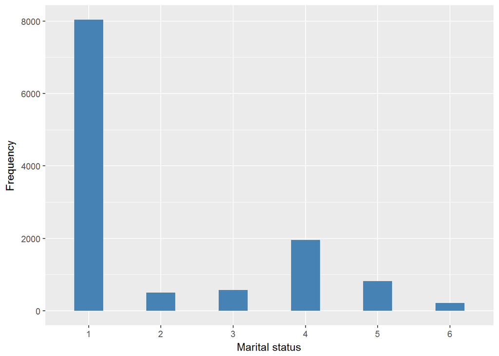

#### 2.1.1.2 Harmonisation algorithm

To compute the harmonize variable from the study-specific variable it has to be recoded as follows:

- `1 OR 2 into 1`
- `3,4,5,6 into 0`
- `NA into 999`

**R script:**

```r
ELSA_ds_w1 <- tibble(id = ELSA_w1_spouse$id)
ELSA_ds_w1$spouse <- car::recode(as.vector(ELSA_w1_spouse$marstat), "1:2='1'; 3:6='0'; NA='999'")
ELSA_ds_w1$spouse <- labelled(ELSA_ds_w1$spouse, labels = c(No = 0, Yes = 1,
    Missing = 999, `Do not know` = 998, Refuse = 997, `Not applicable` = 996,
    `Don't answer` = 995, `Not attempt/not done/not yet recorded` = 994, `Disable to measure` = 993,
    Impute = 992, `CAPI/interviewer error` = 991))
```

#### 2.1.1.3 Statistical description of the new harmonised variable

| Sample size | Missing values |
| --- | --- |
| 12099 | 0 |

Category

|  | 0 | 1 |
| --- | --- | --- |
| Frequency | 3560.00 | 8539.00 |
| Percentage | 29.42 | 70.58 |

Type of missing

|  | 991 | 992 | 993 | 994 | 995 | 996 | 997 | 998 | 999 | NA |
| --- | --- | --- | --- | --- | --- | --- | --- | --- | --- | --- |
| Frequency | 0 | 0 | 0 | 0 | 0 | 0 | 0 | 0 | 0 | 0 |
| Percentage | 0 | 0 | 0 | 0 | 0 | 0 | 0 | 0 | 0 | 0 |

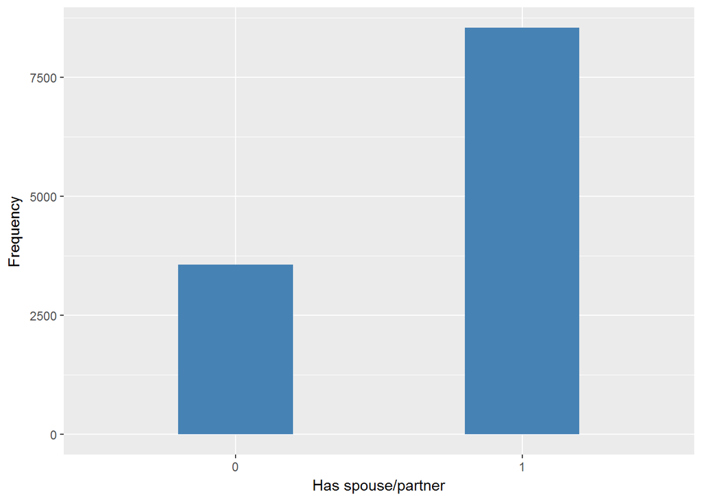

#### 2.1.1.4 Validation

|  | 0 | 1 |
| --- | --- | --- |
| BeforeH | 3560 | 8539 |
| AfterH | 3560 | 8539 |

### 2.1.2 Wave 2

#### 2.1.2.1 Study-specific variable description

The study-specific variable elected to be harmonised is:

- Name: `marstat`
- Label: `marital status - couple1 combined with dimar`
- Categories:
  - `1.0 = married (inc civ pship 06 onwards)`
  - `2.0 = cohabiting`
  - `3.0 = single, never married`
  - `4.0 = widowed`
  - `5.0 = divorced`
  - `6.0 = separated`
- Description:

MARSTAT

| Sample size | Missing values |
| --- | --- |
| 9432 | 0 |

Category

|  | 1 | 2 | 3 | 4 | 5 | 6 |
| --- | --- | --- | --- | --- | --- | --- |
| Frequency | 6185.00 | 407.00 | 418.00 | 1614.00 | 661.00 | 147.00 |
| Percentage | 65.57 | 4.32 | 4.43 | 17.11 | 7.01 | 1.56 |

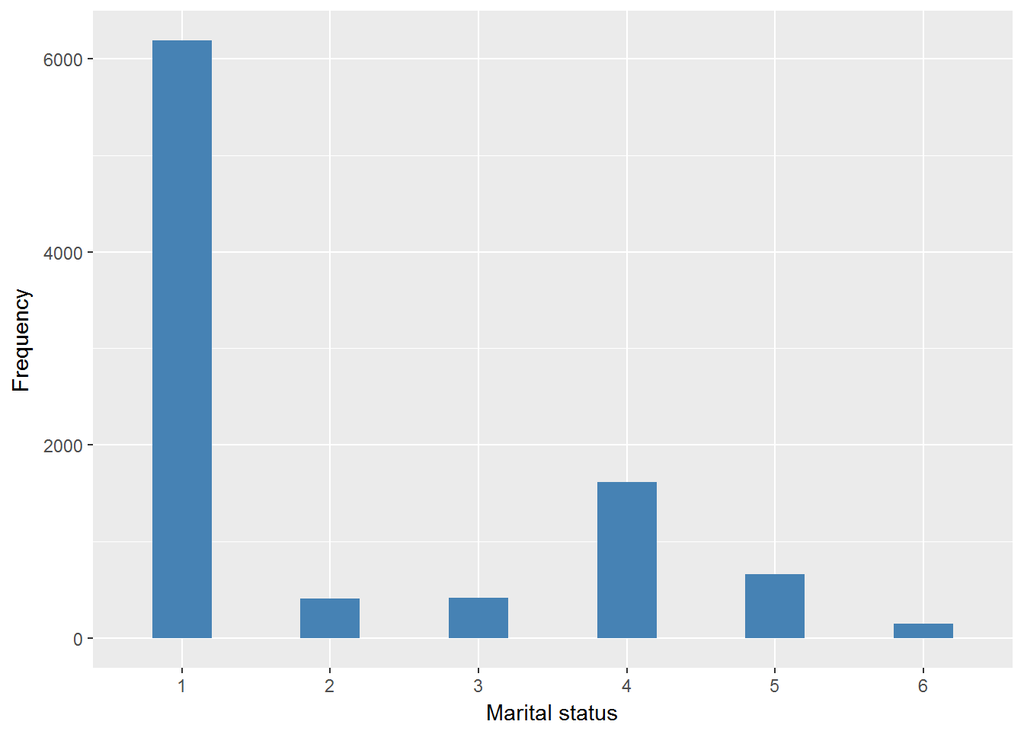

#### 2.1.2.2 Harmonisation algorithm

To compute the harmonize variable from the study-specific variable it has to be recoded as follows:

- `1 OR 2 into 1`
- `3,4,5,6 into 0`
- `NA into 999`

**R script:**

```r
ELSA_ds_w2 <- tibble(id = ELSA_w2_spouse$id)
ELSA_ds_w2$spouse <- car::recode(as.vector(ELSA_w2_spouse$marstat), "1:2='1'; 3:6='0'; NA='999'")
ELSA_ds_w2$spouse <- labelled(ELSA_ds_w2$spouse, labels = c(No = 0, Yes = 1,
    Missing = 999, `Do not know` = 998, Refuse = 997, `Not applicable` = 996,
    `Don't answer` = 995, `Not attempt/not done/not yet recorded` = 994, `Disable to measure` = 993,
    Impute = 992, `CAPI/interviewer error` = 991))
```

#### 2.1.2.3 Statistical description of the new harmonised variable

| Sample size | Missing values |
| --- | --- |
| 9432 | 0 |

Category

|  | 0 | 1 |
| --- | --- | --- |
| Frequency | 2840.00 | 6592.00 |
| Percentage | 30.11 | 69.89 |

Type of missing

|  | 991 | 992 | 993 | 994 | 995 | 996 | 997 | 998 | 999 | NA |
| --- | --- | --- | --- | --- | --- | --- | --- | --- | --- | --- |
| Frequency | 0 | 0 | 0 | 0 | 0 | 0 | 0 | 0 | 0 | 0 |
| Percentage | 0 | 0 | 0 | 0 | 0 | 0 | 0 | 0 | 0 | 0 |

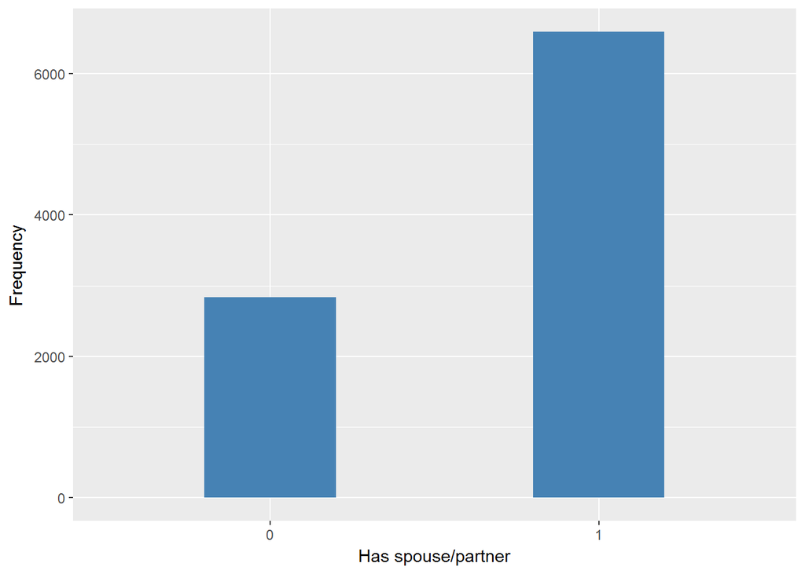

#### 2.1.2.4 Validation

|  | 0 | 1 |
| --- | --- | --- |
| BeforeH | 2840 | 6592 |
| AfterH | 2840 | 6592 |

### 2.1.3 Wave 3

#### 2.1.3.1 Study-specific variable description

The study-specific variable elected to be harmonised is:

- Name: `marstat`
- Label: `marital status - couple1 combined with dimar`
- Categories:
  - `1.0 = married (inc civ pship 06 onwards)`
  - `2.0 = cohabiting`
  - `3.0 = single, never married`
  - `4.0 = widowed`
  - `5.0 = divorced`
  - `6.0 = separated`
- Description:

MARSTAT

| Sample size | Missing values |
| --- | --- |
| 9771 | 0 |

Category

|  | 1 | 2 | 3 | 4 | 5 | 6 |
| --- | --- | --- | --- | --- | --- | --- |
| Frequency | 6402.00 | 498.0 | 460.00 | 1515.00 | 734.00 | 162.00 |
| Percentage | 65.52 | 5.1 | 4.71 | 15.51 | 7.51 | 1.66 |

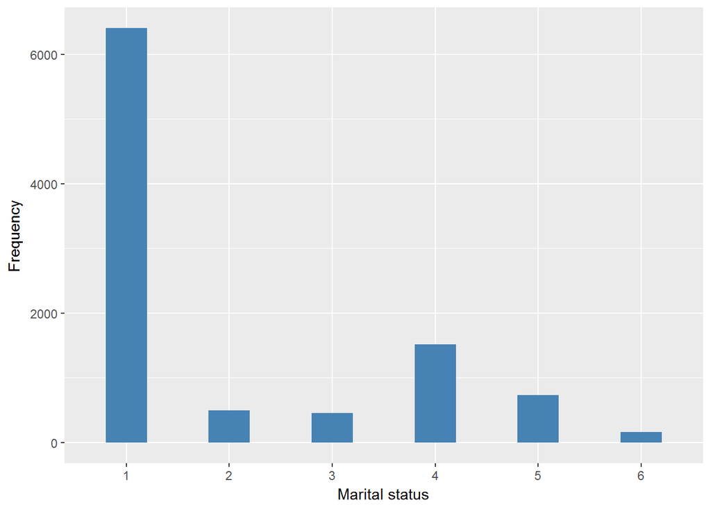

#### 2.1.3.2 Harmonisation algorithm

To recode the harmonize variable from the study-specific variable it has to be recoded as follows:

- `1 OR 2 into 1`
- `3,4,5,6 into 0`
- `NA into 999`

**R script:**

```r
ELSA_ds_w3 <- tibble(id = ELSA_w3_spouse$id)
ELSA_ds_w3$spouse <- car::recode(as.vector(ELSA_w3_spouse$marstat), "1:2='1'; 3:6='0'; NA='999'")
ELSA_ds_w3$spouse <- labelled(ELSA_ds_w3$spouse, labels = c(No = 0, Yes = 1,
    Missing = 999, `Do not know` = 998, Refuse = 997, `Not applicable` = 996,
    `Don't answer` = 995, `Not attempt/not done/not yet recorded` = 994, `Disable to measure` = 993,
    Impute = 992, `CAPI/interviewer error` = 991))
```

#### 2.1.3.3 Statistical description of the new harmonised variable

| Sample size | Missing values |
| --- | --- |
| 9771 | 0 |

Category

|  | 0 | 1 |
| --- | --- | --- |
| Frequency | 2871.00 | 6900.00 |
| Percentage | 29.38 | 70.62 |

Type of missing

|  | 991 | 992 | 993 | 994 | 995 | 996 | 997 | 998 | 999 | NA |
| --- | --- | --- | --- | --- | --- | --- | --- | --- | --- | --- |
| Frequency | 0 | 0 | 0 | 0 | 0 | 0 | 0 | 0 | 0 | 0 |
| Percentage | 0 | 0 | 0 | 0 | 0 | 0 | 0 | 0 | 0 | 0 |

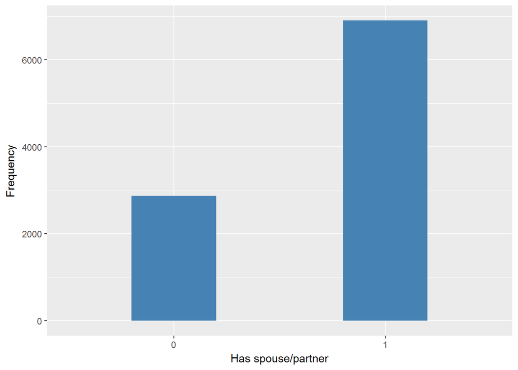

##### 2.1.3.3.1 Validation

|  | 0 | 1 |
| --- | --- | --- |
| BeforeH | 2871 | 6900 |
| AfterH | 2871 | 6900 |

### 2.1.4 Wave 4

#### 2.1.4.1 Study-specific variable description

The study-specific variable elected to be harmonised is:

- Name: `marstat`
- Label: `marital status - couple1 combined with dimar`
- Categories:
  - `1.0 = married (inc civ pship 06 onwards)`
  - `2.0 = cohabiting`
  - `3.0 = single, never married`
  - `4.0 = widowed`
  - `5.0 = divorced`
  - `6.0 = separated`
- Description:

MARSTAT

| Sample size | Missing values |
| --- | --- |
| 11050 | 0 |

Category

|  | 1 | 2 | 3 | 4 | 5 | 6 |
| --- | --- | --- | --- | --- | --- | --- |
| Frequency | 7410.00 | 556.00 | 549.00 | 1538.00 | 861.00 | 136.00 |
| Percentage | 67.06 | 5.03 | 4.97 | 13.92 | 7.79 | 1.23 |

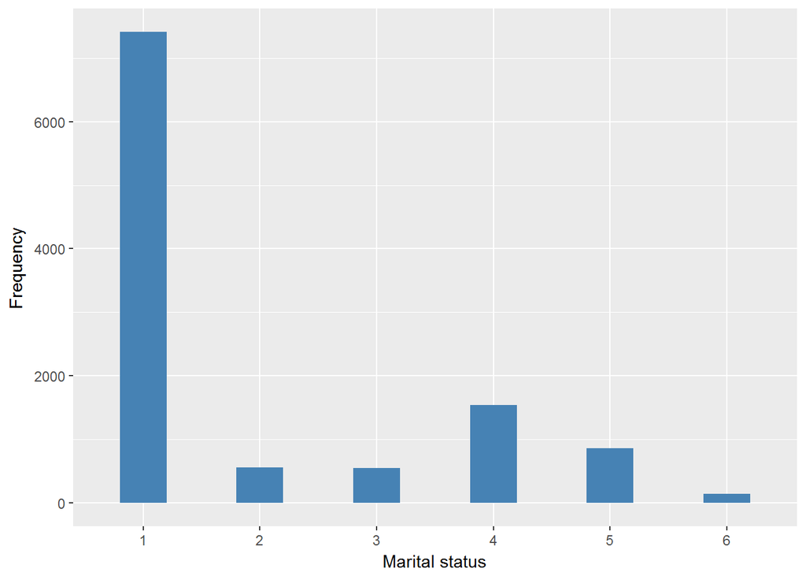

#### 2.1.4.2 Harmonisation algorithm

To recode the harmonize variable from the study-specific variable it has to be recoded as follows:

- `1 OR 2 into 1`
- `3,4,5,6 into 0`
- `NA into 999`

**R script:**

```r
ELSA_ds_w4 <- tibble(id = ELSA_w4_spouse$id)
ELSA_ds_w4$spouse <- car::recode(as.vector(ELSA_w4_spouse$marstat), "1:2='1'; 3:6='0'; NA='999'")
ELSA_ds_w4$spouse <- labelled(ELSA_ds_w4$spouse, labels = c(No = 0, Yes = 1,
    Missing = 999, `Do not know` = 998, Refuse = 997, `Not applicable` = 996,
    `Don't answer` = 995, `Not attempt/not done/not yet recorded` = 994, `Disable to measure` = 993,
    Impute = 992, `CAPI/interviewer error` = 991))
```

#### 2.1.4.3 Statistical description of the new harmonised variable

| Sample size | Missing values |
| --- | --- |
| 11050 | 0 |

Category

|  | 0 | 1 |
| --- | --- | --- |
| Frequency | 3084.00 | 7966.00 |
| Percentage | 27.91 | 72.09 |

Type of missing

|  | 991 | 992 | 993 | 994 | 995 | 996 | 997 | 998 | 999 | NA |
| --- | --- | --- | --- | --- | --- | --- | --- | --- | --- | --- |
| Frequency | 0 | 0 | 0 | 0 | 0 | 0 | 0 | 0 | 0 | 0 |
| Percentage | 0 | 0 | 0 | 0 | 0 | 0 | 0 | 0 | 0 | 0 |

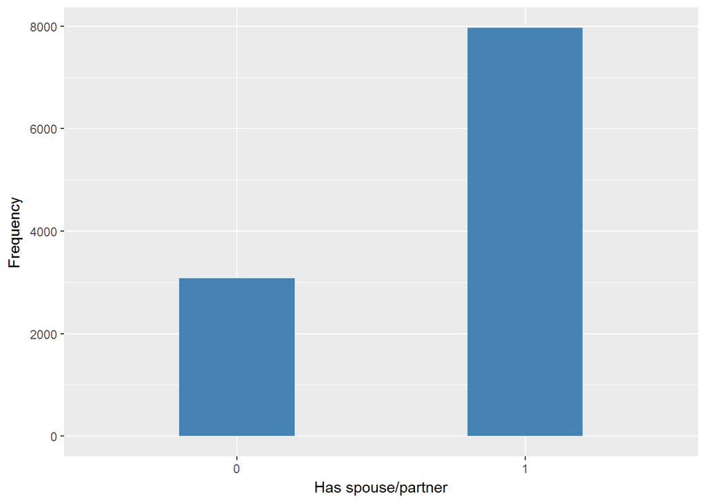

##### 2.1.4.3.1 Validation

|  | 0 | 1 |
| --- | --- | --- |
| BeforeH | 3084 | 7966 |
| AfterH | 3084 | 7966 |

### 2.1.5 Wave 5

#### 2.1.5.1 Study-specific variable description

The study-specific variable elected to be harmonised is:

- Name: `marstat`
- Label: `marital status - couple1 combined with dimar`
- Categories:
  - `1.0 = married (inc civ pship 06 onwards)`
  - `2.0 = cohabiting`
  - `3.0 = single, never married`
  - `4.0 = widowed`
  - `5.0 = divorced`
  - `6.0 = separated`
- Description:

MARSTAT

| Sample size | Missing values |
| --- | --- |
| 10274 | 0 |

Category

|  | 1 | 2 | 3 | 4 | 5 | 6 |
| --- | --- | --- | --- | --- | --- | --- |
| Frequency | 6818.00 | 533.00 | 470.00 | 1520.00 | 819.00 | 114.00 |
| Percentage | 66.36 | 5.19 | 4.57 | 14.79 | 7.97 | 1.11 |

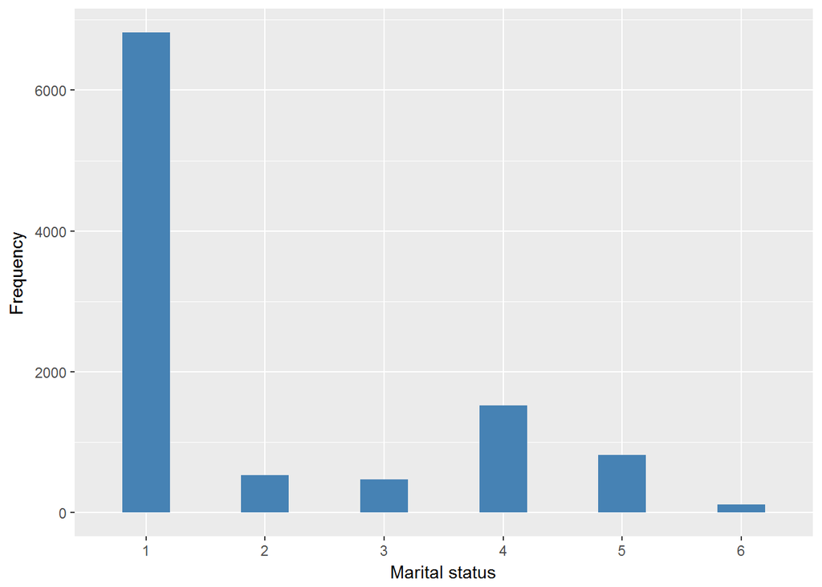

#### 2.1.5.2 Harmonisation algorithm

To recode the harmonize variable from the study-specific variable it has to be recoded as follows:

- `1 OR 2 into 1`
- `3,4,5,6 into 0`
- `NA into 999`

**R script:**

```r
ELSA_ds_w5 <- tibble(id = ELSA_w5_spouse$id)
ELSA_ds_w5$spouse <- car::recode(as.vector(ELSA_w5_spouse$marstat), "1:2='1'; 3:6='0'; NA='999'")
ELSA_ds_w5$spouse <- labelled(ELSA_ds_w5$spouse, labels = c(No = 0, Yes = 1,
    Missing = 999, `Do not know` = 998, Refuse = 997, `Not applicable` = 996,
    `Don't answer` = 995, `Not attempt/not done/not yet recorded` = 994, `Disable to measure` = 993,
    Impute = 992, `CAPI/interviewer error` = 991))
```

#### 2.1.5.3 Statistical description of the new harmonised variable

| Sample size | Missing values |
| --- | --- |
| 10274 | 0 |

Category

|  | 0 | 1 |
| --- | --- | --- |
| Frequency | 2923.00 | 7351.00 |
| Percentage | 28.45 | 71.55 |

Type of missing

|  | 991 | 992 | 993 | 994 | 995 | 996 | 997 | 998 | 999 | NA |
| --- | --- | --- | --- | --- | --- | --- | --- | --- | --- | --- |
| Frequency | 0 | 0 | 0 | 0 | 0 | 0 | 0 | 0 | 0 | 0 |
| Percentage | 0 | 0 | 0 | 0 | 0 | 0 | 0 | 0 | 0 | 0 |

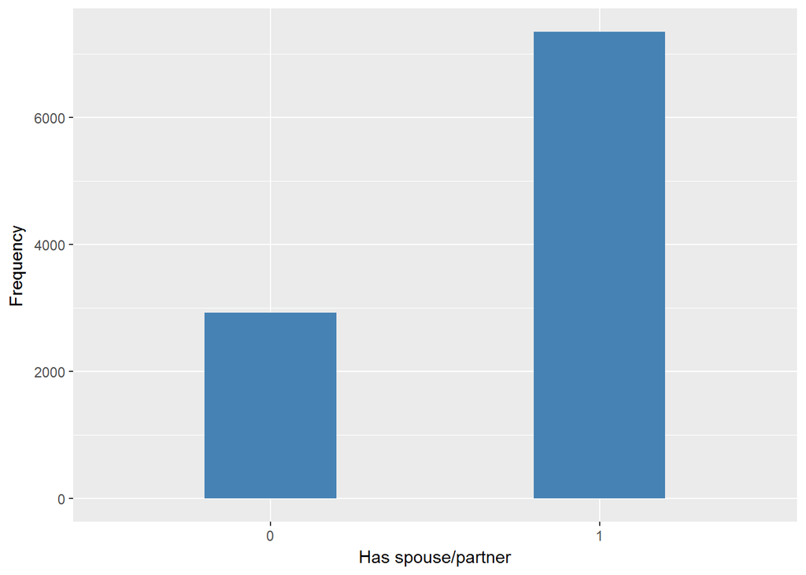

##### 2.1.5.3.1 Validation

|  | 0 | 1 |
| --- | --- | --- |
| BeforeH | 2923 | 7351 |
| AfterH | 2923 | 7351 |

### 2.1.6 Wave 6

#### 2.1.6.1 Study-specific variable description

The study-specific variable elected to be harmonised is:

- Name: `marstat`
- Label: `marital status - couple1 combined with dimar`
- Categories:
  - `1.0 = married (inc civ pship 06 onwards)`
  - `2.0 = cohabiting`
  - `3.0 = single, never married`
  - `4.0 = widowed`
  - `5.0 = divorced`
  - `6.0 = separated`
- Description:

MARSTAT

| Sample size | Missing values |
| --- | --- |
| 10601 | 0 |

Category

|  | 1 | 2 | 3 | 4 | 5 | 6 |
| --- | --- | --- | --- | --- | --- | --- |
| Frequency | 7015.00 | 615.0 | 515.00 | 1480.00 | 847.00 | 129.00 |
| Percentage | 66.17 | 5.8 | 4.86 | 13.96 | 7.99 | 1.22 |

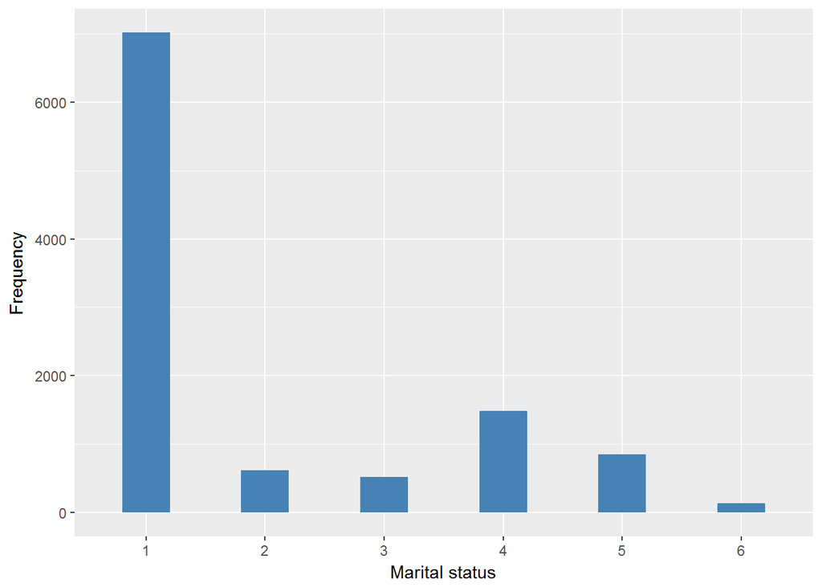

#### 2.1.6.2 Harmonisation algorithm

To recode the harmonize variable from the study-specific variable it has to be recoded as follows:

- `1 OR 2 into 1`
- `3,4,5,6 into 0`
- `NA into 999`

**R script:**

```r
ELSA_ds_w6 <- tibble(id = ELSA_w6_spouse$id)
ELSA_ds_w6$spouse <- car::recode(as.vector(ELSA_w6_spouse$marstat), "1:2='1'; 3:6='0'; NA='999'")
ELSA_ds_w6$spouse <- labelled(ELSA_ds_w6$spouse, labels = c(No = 0, Yes = 1,
    Missing = 999, `Do not know` = 998, Refuse = 997, `Not applicable` = 996,
    `Don't answer` = 995, `Not attempt/not done/not yet recorded` = 994, `Disable to measure` = 993,
    Impute = 992, `CAPI/interviewer error` = 991))
```

#### 2.1.6.3 Statistical description of the new harmonised variable

| Sample size | Missing values |
| --- | --- |
| 10601 | 0 |

Category

|  | 0 | 1 |
| --- | --- | --- |
| Frequency | 2971.00 | 7630.00 |
| Percentage | 28.03 | 71.97 |

Type of missing

|  | 991 | 992 | 993 | 994 | 995 | 996 | 997 | 998 | 999 | NA |
| --- | --- | --- | --- | --- | --- | --- | --- | --- | --- | --- |
| Frequency | 0 | 0 | 0 | 0 | 0 | 0 | 0 | 0 | 0 | 0 |
| Percentage | 0 | 0 | 0 | 0 | 0 | 0 | 0 | 0 | 0 | 0 |

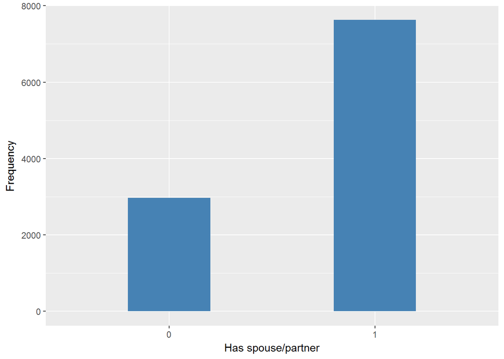

#### 2.1.6.4 Validation

|  | 0 | 1 |
| --- | --- | --- |
| BeforeH | 2971 | 7630 |
| AfterH | 2971 | 7630 |

### 2.1.7 Wave 7

#### 2.1.7.1 Study-specific variable description

The study-specific variable elected to be harmonised is:

- Name: `marstat`
- Label: `marital status - couple1 combined with dimar`
- Categories:
  - `1.0 = married (inc civ pship 06 onwards)`
  - `2.0 = cohabiting`
  - `3.0 = single, never married`
  - `4.0 = widowed`
  - `5.0 = divorced`
  - `6.0 = separated`
- Description:

| Sample size | Missing values |
| --- | --- |
| 9666 | 0 |

Category

|  | 1 | 2 | 3 | 4 | 5 | 6 |
| --- | --- | --- | --- | --- | --- | --- |
| Frequency | 6366.00 | 601.00 | 455.00 | 1341.00 | 779.00 | 124.00 |
| Percentage | 65.86 | 6.22 | 4.71 | 13.87 | 8.06 | 1.28 |

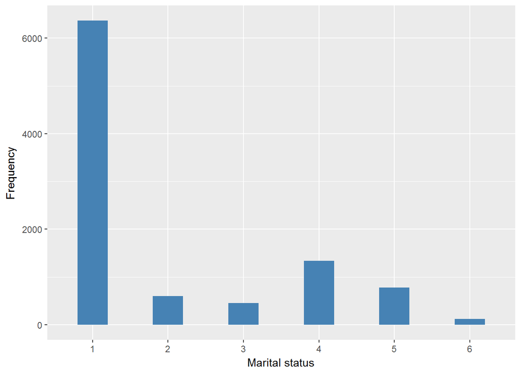

#### 2.1.7.2 Harmonisation algorithm

To recode the harmonize variable from the study-specific variable it has to be recoded as follows:

- `1 OR 2 into 1`
- `3,4,5,6 into 0`
- `NA into 999`

**R script:**

```r
ELSA_ds_w7 <- tibble(id = ELSA_w7$id)
ELSA_ds_w7$spouse <- car::recode(as.vector(ELSA_w7$marstat), "1:2='1'; 3:6='0'; NA='999'")
ELSA_ds_w7$spouse <- labelled(ELSA_ds_w7$spouse, labels = c(No = 0, Yes = 1,
    Missing = 999, `Do not know` = 998, Refuse = 997, `Not applicable` = 996,
    `Don't answer` = 995, `Not attempt/not done/not yet recorded` = 994, `Disable to measure` = 993,
    Impute = 992, `CAPI/interviewer error` = 991))
```

#### 2.1.7.3 Statistical description of the new harmonised variable

| Sample size | Missing values |
| --- | --- |
| 9666 | 0 |

Category

|  | 0 | 1 |
| --- | --- | --- |
| Frequency | 2699.00 | 6967.00 |
| Percentage | 27.92 | 72.08 |

Type of missing

|  | 991 | 992 | 993 | 994 | 995 | 996 | 997 | 998 | 999 | NA |
| --- | --- | --- | --- | --- | --- | --- | --- | --- | --- | --- |
| Frequency | 0 | 0 | 0 | 0 | 0 | 0 | 0 | 0 | 0 | 0 |
| Percentage | 0 | 0 | 0 | 0 | 0 | 0 | 0 | 0 | 0 | 0 |

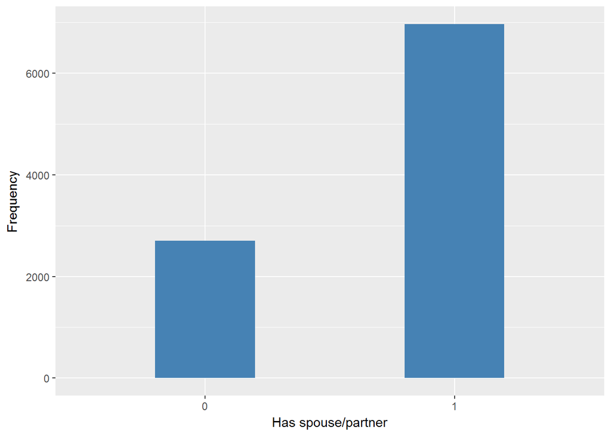

#### 2.1.7.4 Validation

|  | 0 | 1 |
| --- | --- | --- |
| BeforeH | 2699 | 6967 |
| AfterH | 2699 | 6967 |

# 3 Quality estimation